# An Introduction to the Twitter API and Sentiment Analysis

Robyn Ferg

February 24, 2020

# rtweet

** Demonstration is adapted from rtweet documentation - https://github.com/mkearney/rtweet **

## Loading rtweet

First, run this code to install and load the library, rtweet.

NOTE: You will also need a Twitter account to run this code.

```r
#install.packages('rtweet')
library(rtweet)
```

## search_tweets

Firstly, we can use the Twitter search API to pull previously tweeted tweets - this function behaves the same as doing a search in the twitter search bar, returns a bunch of variables in a JSON format and then rtweet turns it into a dataframe for us.

In this example, we’re searching for tweets that include the hashtag #rstats, and limiting our results to 100 maximum. The include_rts argument indicates whether or not you want your results to include retweets. In this example we have set that to FALSE, so we would only get original tweets. Search_tweets using the standard Twitter API (the free version) will only pull historical tweets within the past week.

As you work through this notebook, if you run each cell in rapid succession you may hit a rate limit. You can only collect 18,000 tweets per 15 minutes. If I hit a rate limit I set a timer for 15 minutes and work on something else in the meantime. I’m going to limit many of these examples to 100 tweets each to avoid hitting rate limits.

```r
rstats = search_tweets("#rstats", n = 100, include_rts = FALSE)
```

Tweets from the last 6-9 days are collected, lets look at a 10.

```r
head(rstats$text, n=10)
```

```
##  [1] "In honor of last night's Grammy Awards, I decided to use the awards show as the theme for my newest post!  #rstats #datascience #r https://t.co/Cko4LUN9bD"
##  [2] "At an @EdwardTufte seminar learning all the data presentation things.\n\n#rstats https://t.co/vIkKGp2WYh"
##  [3] "🗣🗣🗣 Abstracts are due this Friday January 31st AOE for #UMAP2020. Full papers are due February 7th. \n\nLearn more: https://t.co/yLoL7T0FTp\n\n@ACM_SIGWEB @sigchi #TidyTuesday #rstats #AcademicChatter #AcademicTwitter https://t.co/Hn306xVgKK"
##  [4] "I'm in San Francisco! See ya soon, #rstats tweeps! #rstudioconf"
##  [5] "It was great spending a Saturday afternoon with the Analyze This! R for Data Science Study Group! If you want to learn #rstats for Data Science, it's not too late to join!\n\n#datascience #machinelearning #analytics #dataanalytics #studygroup #data https://t.co/2BYcfZYO9S"
##  [6] "Introduction to #Kubernetes  Deployment Using Helm | #BigData #Analytics #DataScience #AI #MachineLearning #IoT #IIoT #PyTorch #Python #RStats #TensorFlow #Java #JavaScript #ReactJS #GoLang #CloudComputing #Serverless #DataScientist | via @gp_pulipaka | https://t.co/4ePZFS004Q https://t.co/…
##  [7] "Machine Learning Necessary for #DeepLearning | #BigData #Analytics #DataScience #AI #MachineLearning #IoT #IIoT #PyTorch #Python #RStats #TensorFlow #Java #JavaScript #ReactJS #GoLang #CloudComputing #DataScientist #Linux #Statistics | via @gp_pulipaka | https://t.co/otD4EDLzn1 https://t.co…
##  [8] "Conjugate Prior Explained | #BigData  #Analytics #DataScience #AI #MachineLearning #IoT #IIoT #PyTorch #Python #RStats #TensorFlow #Java #JavaScript #ReactJS #GoLang #CloudComputing #Serverless #DataScientist #Linux #Statistics via @gp_pulipaka | https://t.co/6JL8oYYJVd https://t.co/iRyYtd6…
##  [9] "Stupidly excited for #rstudioconf2020 this week! \n\n📢 Check out my lightening talk on \"becoming an R blogger\" Thursday at 2:55. \n\n👋 If you'd like to say hi during the conference, feel free to reach out\n\n#rstats #datascience"
## [10] "Sci hub download statistics are out and dataset is rich. Can this dataset go for #TidyTuesday @hadleywickham @Sci_Hub \n#sciencetwitter #rstats @tidypod \n#opensourceresearch https://t.co/vVeLoStQtG"
```

In search_tweets we can use AND to find tweets that contain both #rstats AND the word data, in any position within the text. The space works as an AND search.

```r
rstats2 = search_tweets("#rstats data", n = 100, include_rts = FALSE)
```

Here we find tweets that contain both #rstats and also the word data.

```r
head(rstats2$text, n=10)
```

```
##  [1] "At an @EdwardTufte seminar learning all the data presentation things.\n\n#rstats https://t.co/vIkKGp2WYh"
##  [2] "It was great spending a Saturday afternoon with the Analyze This! R for Data Science Study Group! If you want to learn #rstats for Data Science, it's not too late to join!\n\n#datascience #machinelearning #analytics #dataanalytics #studygroup #data https://t.co/2BYcfZYO9S"
##  [3] "I got used to virtual Hadley following me around the web trying to teach me #rstats, I guess soon enough I'll hardly notice the ads for data science bootcamps"
##  [4] "#data #datascience #it #tech #technology #technologie #Science #css #javascript #computerscience #future #smartphone #BigData #Analytics #DataScience #AI #MachineLearning #ReinforcementLearning #IoT #IIoT #PyTorch #Python #RStats #TensorFlow #Java #JavaScript #ReactJS"
##  [5] "#data #datascience #it #tech #technology #technologie #Science #css #javascript #computerscience #future #smartphone #BigData #Analytics #DataScience #AI #MachineLearning #ReinforcementLearning #IoT #IIoT #PyTorch #Python #RStats #TensorFlow #Java #JavaScript #ReactJS"
##  [6] "#data #datascience #it #tech #technology #technologie #Science #css #javascript #computerscience #future #smartphone #BigData #Analytics #DataScience #AI #MachineLearning #ReinforcementLearning #IoT #IIoT #PyTorch #Python #RStats #TensorFlow #Java #JavaScript #ReactJS #GoLang"
##  [7] "#data #datascience #it #tech #technology #technologie #Science #css #javascript #computerscience #future #smartphone #BigData #Analytics #DataScience #AI #MachineLearning #ReinforcementLearning #IoT #IIoT #PyTorch #Python #RStats #TensorFlow #Java #JavaScript #ReactJS"
##  [8] "#data #datascience #it #tech #technology #technologie #Science #css #javascript #computerscience #future #smartphone #BigData #Analytics #DataScience #AI #MachineLearning #ReinforcementLearning #IoT #IIoT #PyTorch #Python #RStats #TensorFlow #Java #JavaScript #ReactJS"
##  [9] "#data #datascience #it #tech #technology #technologie #Science #css #javascript #computerscience #future #smartphone #BigData #Analytics #DataScience #AI #MachineLearning #ReinforcementLearning #IoT #IIoT #PyTorch #Python #RStats #TensorFlow #Java #JavaScript #ReactJS"
## [10] "#data #datascience #it #tech #technology #technologie #Science #css #javascript #computerscience #future #smartphone #BigData #Analytics #DataScience #AI #MachineLearning #ReinforcementLearning #IoT #IIoT #PyTorch #Python #RStats #TensorFlow #Java #JavaScript #ReactJS"
```

Let’s try an OR instead of an AND search. See the twitter search documentation for standard search operators: https://developer.twitter.com/en/docs/tweets/search/guides/standard-operators

```r
rstats3 = search_tweets("#rstats OR data", n = 100, include_rts = FALSE)
```

Here we find more variety of tweets as they contain either #rstats or the fairly common word “data.”

```r
head(rstats3$text, n=10)
```

```
##  [1] "@blckbonaventura Thank you for providing this feedback, we will certainly make sure this is forwarded to our game team for further review. If possible could you also confirm the data center you are attempting to access if known.?"
##  [2] "Klaviyo has developed a system that analyzes disparate data points, often in real-time, on individual customers and prospects, to automate personalized communications."
##  [3] "@RLuzmore Im keen to try and suss our how transition works in an all through school. Do you have anyone in a role that focuses on it? What SENCo roles do you have? Do you know if your data is more consistent between primary&amp; secondary than separate schools?"
##  [4] "\"Private equity investors push data center M&amp;A to new heights in 2019 - report: Last year the number of data center mergers and acquisitions deals closed passed the 100 mark for the first time, according to a report. Synergy Research https://t.co/LcAyIu5tSx h/t FierceTelecom https://t.…
##  [5] "Avast sells your search and browsing data according to new report https://t.co/zP7HUXtImP"
##  [6] "GS-Preprocess: Containerized GUIDE-seq Data Analysis Tools with Diverse Sequencer Compatibility https://t.co/OALjDNx4o6"
##  [7] "@pahowdy @DeWitt_Dynasty @DestinationDevy @RayGQue @JesseReevesFF Yup, love your DB. I wasn't suggesting REC&gt;YD. \nI was wondering if (REC+YD)&gt;(TD+YD) as a predictive metric. Just pondering is all and wondered if you had a feel for it.\n\nSo much data to consider. I haven't even consi…
##  [8] "@Mczack11 Hello Zack, kindly note data billing is strictly based on volumes accessed as opposed to time and duration. ^Caro"
##  [9] "@americanascom Estou aguardando a entrega de um produto que comprei na Blackfriday com data de entrega em 15/01/2020(45 dias) e até agora nada. Não consigo me comunicar nem pelo chat do site e nem pelo tele atendimento. Será que alguém me responde no Twitter?"
## [10] "@DaveWCronin @diegbro YOU GUYS!!!! Did read an article where a guy was able to pull data from millions of transactions (not private banking info or anything) but his biggest takeaway was to make all of your transactions private for data security reasons. The more you know!"
```

## Variables in Twitter Data

```r
# LIST VARIABLE NAMES
colnames(rstats)
```

```
##  [1] "user_id"                 "status_id"
##  [3] "created_at"              "screen_name"
##  [5] "text"                    "source"
##  [7] "display_text_width"      "reply_to_status_id"
##  [9] "reply_to_user_id"        "reply_to_screen_name"
## [11] "is_quote"                "is_retweet"
## [13] "favorite_count"          "retweet_count"
## [15] "quote_count"             "reply_count"
## [17] "hashtags"                "symbols"
## [19] "urls_url"                "urls_t.co"
## [21] "urls_expanded_url"       "media_url"
## [23] "media_t.co"              "media_expanded_url"
## [25] "media_type"              "ext_media_url"
## [27] "ext_media_t.co"          "ext_media_expanded_url"
## [29] "ext_media_type"          "mentions_user_id"
```

[output cut: 30 more lines]

## What are retweets?

So far we’ve limited our tweets obtained in our searches to original tweets by utilizing the `include_rts = FALSE` argument. What are retweets? Retweets are probably the most common type of tweet on twitter. Retweets are when users share the tweets of others on their own twitter timeline with attribution.

## Using Collected Tweet Data - Tweets over Time

We can make various plots using this saved data, for example, graphing the number of tweets by timeperiod.

```r
#install.packages('ggplot2')
library(ggplot2)
```

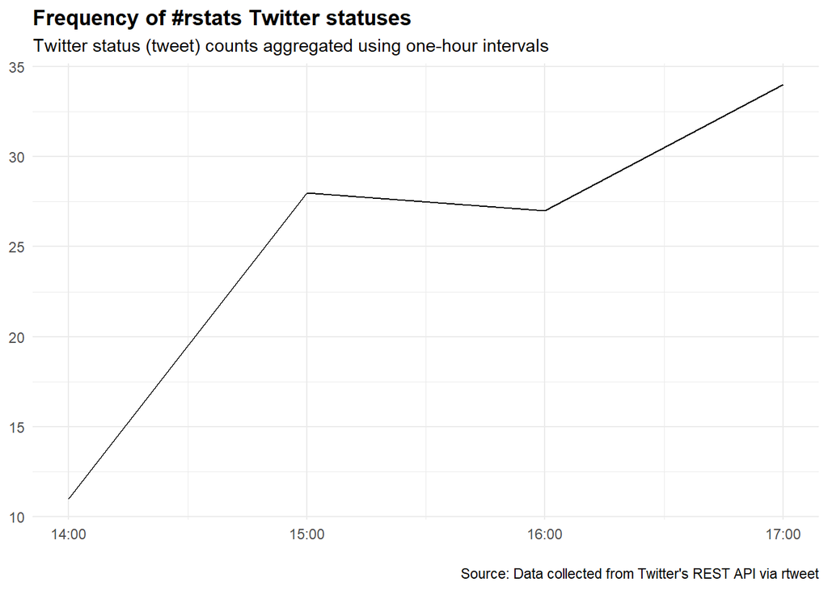

```r
ts_plot(rstats, "1 hours") +
  ggplot2::theme_minimal() +
  ggplot2::theme(plot.title = ggplot2::element_text(face = "bold")) +
  ggplot2::labs(
    x = NULL, y = NULL,
    title = "Frequency of #rstats Twitter statuses",
    subtitle = "Twitter status (tweet) counts aggregated using one-hour intervals",
    caption = "\nSource: Data collected from Twitter's REST API via rtweet"
  )
```

# “Listening” to Twitter

## stream_tweets

So far we have done our analysis on past tweets through the search API. For most research applications you will want to “listen” to the twitter stream and obtain a 1% sample of all tweets as they are posted, 1) because you can monitor emerging situations and 2) because with a free account you are limited to searching the last 6-9 days, but you can stream continuously over a period of time to compile a corpus of tweets for analysis. You will likely obtain more tweets when streaming vs. searching, but streaming API doesn’t have as many operators to be used in keywords - search_tweets has options for NOT searches, types of media (containing an image or a periscope). You also cannot exclude retweets easily when streatming.

The most basic is obtaining a random sample, using no filters. We specify rtweet to listent for 10 seconds (The timeout argument is in seconds). rtweet will default to 30 seconds unless otherwise specified.

```r
library(rtweet)
st = stream_tweets(timeout=10, parse=TRUE)
```

## What do the tweets say?

```r
#PRINT TEXT OF LAST 10 TWEETS IN TABLE
tail(st$text, n=10)
```

```
##  [1] "je suis plus un clown, je suis carrément le cirque entier là"
##  [2] "Oi @mizanzuk \nQuero parte 2 do anticast #bbb pq preciso retirar meu apoio ao babu\nObrigada"
##  [3] "I'm back!!!!! 🤙🤙🤙🤙\n\n by @Roman_Empire_76  #AhYessir \n\n#RomanReigns #RomanEmpire https://t.co/zWxZH8Bogf"
##  [4] "What the fuck just happened? https://t.co/tdXkY8Ap7p"
##  [5] "Ces nouveaux algorithmes qui permettent au fisc de débusquer des milliers de fraudeurs https://t.co/paskuag5wN via @01net"
##  [6] "Crypto Panic: Is This The Fuel For The Next Bitcoin Price Pump? $60 Million Tether (USDT) Just Minted https://t.co/18WA1w0rPM 🙋 1X2T Token Launch via⟶ https://t.co/02Jo1tFKiP"
##  [7] "Feeling bit sad for shehnaz and paras.\nGoing in the same house where they made memories with sid/mahira.\nCaptain room, sidnaz bed, that ballon bed in bathroom, the vivo chair.. \n \nThese memories will haunt them.\n#SidharthShuklaFever #ShehnazGill #ParasChabbra #MujhseShadiKaroge"
##  [8] "So proud to call @HeatherGatnarek my friend!"
##  [9] "@ChrisDJackson @JoeBiden @MikeBloomberg So you believe the lives of the animals you're so proud of bragging about rescuing in your bio are more important than the lives and happiness of 99% of the American people?\n\nPriorities Chris.\n\n#MedicareForAll"
## [10] "Breaking, at pre-trial hearing for Julian Assange a court has heard that he will be calling a witness who will allege he was offered a pardon by the US government, if he would say Russia was not involved in the leak of DNC documents during the 2006 election."
```

Some of what you receive in the text might look like gibberish. These tweets may need to be cleaned before performing text analysis.

## Filtering the Stream

You can also listen for specific filter items (search terms).

With the Deomcratic primary coming up, we’ll listen for tweets about Joe Biden, Bernie Sanders, Elizabeth Warren, and Pete Buttigeig. We will listen for 10 seconds again. The comma serves as an “OR” search. This will not find tweets that call Elizabeth Warren “Warren” or “Sen. Warren,” it requires both Elizabeth AND Warren.

```r
demCandidates = stream_tweets("joe biden, bernie sanders, elizabeth warren, pete buttigieg", timeout = 10)
```

## What do our Democratic candidate tweets say?

```r
#PRINT TEXT OF FIRST 10 TWEETS IN TABLE
head(demCandidates$text, n=10)
```

```
##  [1] "BREAKING: New ABC Nationwide Poll Shows Bernie Sanders in a Commanding 16 point lead in 1st Place.\n\nCANDIDATES % NATIONWIDE:\n\n- Bernie Sanders 32%\n- Joe Biden 16%\n- Mike Bloomberg 14%\n- Liz Warren 12%\n- Pete Buttigieg 8%\n- Amy Klobuchar 7%\n\nKEEP FIGHTING &amp; BERNIE WINS!"
##  [2] "@JoeBiden They released this just in time for you to use it tonight. https://t.co/eNW9KXRC0Z"
##  [3] "This analysis about moderates splitting the field and helping Bernie was accurate until recently. Now Bernie beats every dem in a head to head matchup. Also Voters dont fall into these imagined ideological lanes. If Biden drops many of his supporters will go to Bernie. https://t.co/qHBcAOu1…
##  [4] "guys, however bad you think the opening 2 paragraphs of this article can be, theyre worse"
##  [5] "\"But there is a smarter, even-tempered, non-oligarch candidate who has never stopped, frisk, ignored or incarcerated a black body. Yes, Virginia, there is an Elizabeth Warren. She exists.\"\n\n-- @michaelharriot \n\nhttps://t.co/6UEtmM9hIK"
##  [6] "Alice Johnson responds to Bernie Sanders criticizing President @realDonaldTrump after he granted clemency to Judith Negron, Tynice Nichole Hall, and Crystal Munoz:\n\n\"Anyone who thinks that these women should not have been granted clemency have not looked at their cases.\" https://t.co/sD…
##  [7] "a trans woman going to bat for disclosing full medical histories is going to give me a stroke"
##  [8] "Bernie Sanders did literally exactly what is described in this first sentence months ago, but somehow today the whole liberal commentariat in coordination is doing the ~Long Form Medical Records~ fake controversy again. Feel free to tell them to fuck off, again."
##  [9] "Facts:\n\nMike Bloomberg said Chinas dictator, Xi Jinping, is not a dictator\n\nJoe Biden says that China is not a threat\n\nBernie Sanders said China has done more to address extreme poverty than any country in history\n\nWhy are Democrats so friendly to Americas greatest enemy?"
## [10] "@BurritoAttack @j_salvo @lane_lawless @jaykayokay2020 @soledadobrien https://t.co/EqBM1GIIL5\n\nHere, he did release them, but lmgtfy"
```

Remember this is ~1% of all tweets about either of the four candidates within a 10 second period.

Note that it includes tweets about Joe Biden OR Bernie Sanders OR Elizabeth Warren OR Pete Buttigeig. The comma in the keyword string serves as an OR search.

FROM THE TWITTER API DOCUMENTATION: “A comma-separated list of phrases which will be used to determine what Tweets will be delivered on the stream. A phrase may be one or more terms separated by spaces, and a phrase will match if all of the terms in the phrase are present in the Tweet, regardless of order and ignoring case. By this model, you can think of commas as logical ORs, while spaces are equivalent to logical ANDs (e.g. ‘the twitter’ is the AND twitter, and ‘the,twitter’ is the OR twitter).” Standard stream parameters available at https://developer.twitter.com/en/docs/tweets/filter-realtime/guides/basic-stream-parameters.html. Scroll down to the section titled “track.”

Instead, we want to get tweets that include Joe Biden AND Bernie Sanders AND Elizabeth Warren AND Pete Buttigieg and allow for not including first names. This time we’ll save the tweets in raw JSON format inside your working directory. Afterwards we’ll parse the JSON file using a different function, parse_stream, to convert to a data frame.

```r
stream_tweets(
  "biden sanders warren buttigieg",
  timeout = 30,
  parse=FALSE,#parse= FALSE to save as raw JSON
  file_name = "tweets"
)
```

```r
demCandidates_all = parse_stream("tweets.json")
```

## What do our Biden AND Sanders AND Warren AND Buttigieg tweets say?

```r
#PRINT TEXT OF FIRST 10 TWEETS
head(demCandidates_all$text, n=10)
```

```
##  [1] "NEW South Carolina poll from Change Research has @BernieSanders tied for the lead! (2/12-14):\n\nSanders 23%\nBiden 23%\nSteyer 20%\nButtigieg 15%\nWarren 9%\nKlobuchar 8%\nGabbard 1%\n\nhttps://t.co/gcTfmOL9DG"
##  [2] "#SouthCarolina Democratic Primary Polling:\n\nBiden: 23% (-2)\nSanders: 23% (+3)\nSteyer: 20% (+2)\nButtigieg: 15% (+8)\nWarren: 9% (-2)\nKlobuchar: 8% (+6)\n\nChangePolls / February 14, 2020 / n=1015 / Online\n\n(% chg w Jan 29)\n\n#Democrats #USA #DemDebate"
##  [3] "Bernie  and I can't stress this enough  Beats Trump"
##  [4] "#National ABC/WaPost GE Poll:\n\nSanders 53% (+11)\nTrump 42%\n\nBloomberg 52% (+9)\nTrump 43%\n\nBiden 52% (+8)\nTrump 44%\n\nButtigieg 50% (+7)\nTrump 43%\n\nWarren 50% (+5)\nTrump 45%\n\nKlobuchar 48% (+3)\nTrump 45%\n\nAmong \"All Adults\"\n\n#BernieBeatsTrump #BernieIsTheFrontRunner"
##  [5] "Changes in our nat'l polling average since 2/13 (when we started to get the first hints of post-NH data). Basically everything is stagnant EXCEPT Sanders may be gaining further.\n\nSanders +2.5\n\nBloomberg +0.8\nBiden -0.2\nButtigieg +1.0\nWarren +0.1\nKlob +1.0\n\nhttps://t.co/NRHApT7FSF"
##  [6] "white women have abused their voting privileges for long enough, time to pack it in! enough is enough. i beg you to stop voting lol. https://t.co/4lGbZ5qkiF"
##  [7] "From new @EmersonPolling national poll\n\nTrump's approval rating with each candidates' supporters:\n\nKlobuchar supporters 22%\nButtigieg supporters 11%\nBloomberg supporters 10%\nBiden supporters 10%\nWarren supporters 9%\nSanders supporters 4%"
##  [8] "Changes in our nat'l polling average since 2/13 (when we started to get the first hints of post-NH data). Basically everything is stagnant EXCEPT Sanders may be gaining further.\n\nSanders +2.5\n\nBloomberg +0.8\nBiden -0.2\nButtigieg +1.0\nWarren +0.1\nKlob +1.0\n\nhttps://t.co/NRHApT7FSF"
##  [9] "#Youth Democratic Support Polling:\n\nSanders: 53% (+3)\nWarren: 17% (-1)\nButtigieg: 9% (+1)\nBiden: 7% (-)\nBloomberg: 3% (+1)\nKlobuchar: 3% (-)\n\nChegg-In/College Pulse / February 18, 2020 / n=1500 / Online\n\n(% chg w Feb 11)\n\n#Democrats #DemDebate #USA https://t.co/9e52W9ck6F"
## [10] "Changes in our nat'l polling average since 2/13 (when we started to get the first hints of post-NH data). Basically everything is stagnant EXCEPT Sanders may be gaining further.\n\nSanders +2.5\n\nBloomberg +0.8\nBiden -0.2\nButtigieg +1.0\nWarren +0.1\nKlob +1.0\n\nhttps://t.co/NRHApT7FSF"
```

```r
print("TWEET TEXT")
```

```
## [1] "TWEET TEXT"
```

```r
head(demCandidates_all$text, n=5)
```

```
## [1] "NEW South Carolina poll from Change Research has @BernieSanders tied for the lead! (2/12-14):\n\nSanders 23%\nBiden 23%\nSteyer 20%\nButtigieg 15%\nWarren 9%\nKlobuchar 8%\nGabbard 1%\n\nhttps://t.co/gcTfmOL9DG"
## [2] "#SouthCarolina Democratic Primary Polling:\n\nBiden: 23% (-2)\nSanders: 23% (+3)\nSteyer: 20% (+2)\nButtigieg: 15% (+8)\nWarren: 9% (-2)\nKlobuchar: 8% (+6)\n\nChangePolls / February 14, 2020 / n=1015 / Online\n\n(% chg w Jan 29)\n\n#Democrats #USA #DemDebate"
## [3] "Bernie  and I can't stress this enough  Beats Trump"
## [4] "#National ABC/WaPost GE Poll:\n\nSanders 53% (+11)\nTrump 42%\n\nBloomberg 52% (+9)\nTrump 43%\n\nBiden 52% (+8)\nTrump 44%\n\nButtigieg 50% (+7)\nTrump 43%\n\nWarren 50% (+5)\nTrump 45%\n\nKlobuchar 48% (+3)\nTrump 45%\n\nAmong \"All Adults\"\n\n#BernieBeatsTrump #BernieIsTheFrontRunner"
## [5] "Changes in our nat'l polling average since 2/13 (when we started to get the first hints of post-NH data). Basically everything is stagnant EXCEPT Sanders may be gaining further.\n\nSanders +2.5\n\nBloomberg +0.8\nBiden -0.2\nButtigieg +1.0\nWarren +0.1\nKlob +1.0\n\nhttps://t.co/NRHApT7FSF"
```

```r
print("RETWEET TEXT")
```

```
## [1] "RETWEET TEXT"
```

```r
head(demCandidates_all$retweet_text, n=5)
```

```
## [1] "NEW South Carolina poll from Change Research has @BernieSanders tied for the lead! (2/12-14):\n\nSanders 23%\nBiden 23%\nSteyer 20%\nButtigieg 15%\nWarren 9%\nKlobuchar 8%\nGabbard 1%\n\nhttps://t.co/gcTfmOL9DG"
## [2] "#SouthCarolina Democratic Primary Polling:\n\nBiden: 23% (-2)\nSanders: 23% (+3)\nSteyer: 20% (+2)\nButtigieg: 15% (+8)\nWarren: 9% (-2)\nKlobuchar: 8% (+6)\n\nChangePolls / February 14, 2020 / n=1015 / Online\n\n(% chg w Jan 29)\n\n#Democrats #USA #DemDebate"
## [3] "Bernie  and I can't stress this enough  Beats Trump"
## [4] "#National ABC/WaPost GE Poll:\n\nSanders 53% (+11)\nTrump 42%\n\nBloomberg 52% (+9)\nTrump 43%\n\nBiden 52% (+8)\nTrump 44%\n\nButtigieg 50% (+7)\nTrump 43%\n\nWarren 50% (+5)\nTrump 45%\n\nKlobuchar 48% (+3)\nTrump 45%\n\nAmong \"All Adults\"\n\n#BernieBeatsTrump #BernieIsTheFrontRunner"
## [5] "Changes in our nat'l polling average since 2/13 (when we started to get the first hints of post-NH data). Basically everything is stagnant EXCEPT Sanders may be gaining further.\n\nSanders +2.5\n\nBloomberg +0.8\nBiden -0.2\nButtigieg +1.0\nWarren +0.1\nKlob +1.0\n\nhttps://t.co/NRHApT7FSF"
```

```r
print("QUOTE TWEET TEXT")
```

```
## [1] "QUOTE TWEET TEXT"
```

```r
head(demCandidates_all$quoted_text, n=5)
```

```
## [1] NA
## [2] NA
## [3] "National GE:\nSanders 53% (+11)\nTrump 42%\n.\nBloomberg 52% (+9)\nTrump 43%\n.\nBiden 52% (+8)\nTrump 44%\n.\nButtigieg 50% (+7)\nTrump 43%\n.\nWarren 50% (+5)\nTrump 45%\n.\nKlobuchar 48% (+3)\nTrump 45%\n\n@ABC/@washingtonpost, Among All Adults, 2/14-17\nhttps://t.co/jrnLVZBfzW"
## [4] NA
## [5] NA
```

## Listening Over Time

Here is example code for the listening you will be doing for your project. In the “q” variable you will list your keywords for your searches, using spaces for AND and commas for OR. For you assignment you will want to collected tweets related to basketball, so you will need to change the query to words such as ‘Michigan basketball’, ‘basketball #goblue’, etc.

IMPORTANT: If you’re going to leave your computer on to run this over time, make sure to set your power and sleep settings so that the PC will not go to sleep. If it does, your code will stop and you will lose data and have to restart it.

```r
## Stream keywords used to filter tweets
q = "joe biden, joebiden, bernie sanders, berniesanders, elizabeth warren, ewarren, pete buttigieg, petebuttigieg"
## Put your selected filter terms here ^^^^,separated by commas.
## The commas serve as an OR search. Spaces, as in "joe biden" serve as an AND search
## where both items need to appear in the same tweet, but not necessarily next to each other.
## NOTE -joebiden and joe biden do not return the same results.

## Stream time in seconds so for one minute set timeout = 60
## For larger chunks of time, I recommend multiplying 60 by the number
## of desired minutes. This method scales up to hours as well
## (x * 60 = x mins, x * 60 * 60 = x hours)

# timeout =  60 * 60 * 24  # timeout for one day
timeout = 30 # timeout for 30 seconds

## Monitor your progress, you may have to restart your code if the internet blips or
## if your computer restarts.  By not parsing and saving the raw JSON, you should hopefully not lose any data.

stream_tweets(
  q,
  parse = FALSE,
  timeout = timeout,
  file_name = "tweets1")
stream_tweets(
  q,
  parse = FALSE,
  timeout = timeout,
  file_name = "tweets2")
```

## Parsing JSONS and appending dataframes

```r
## Parse from json file to get a usable dataframe
tweets1 = parse_stream("tweets1.json") #replace tweets1 with the name of the json file
tweets2 = parse_stream("tweets2.json") #check your folder and see how many stream files you have, parse each into a separate dataframe, then bind using the code below, adding each df name to the rbind function
all_tweets = rbind(tweets1, tweets2)
```

## Monitor Your Output

You may want to use a series of shorter listening times (such as 1 day) and at the end of each day inspect the tweets you’ve received for trends so that you can add any emerging hashtags to your filter terms.

## Very Basic Text Mining - Bag of Words

```r
#install.packages('qdap')
library(qdap)
```

## The Bag of Democratic Candidate Words

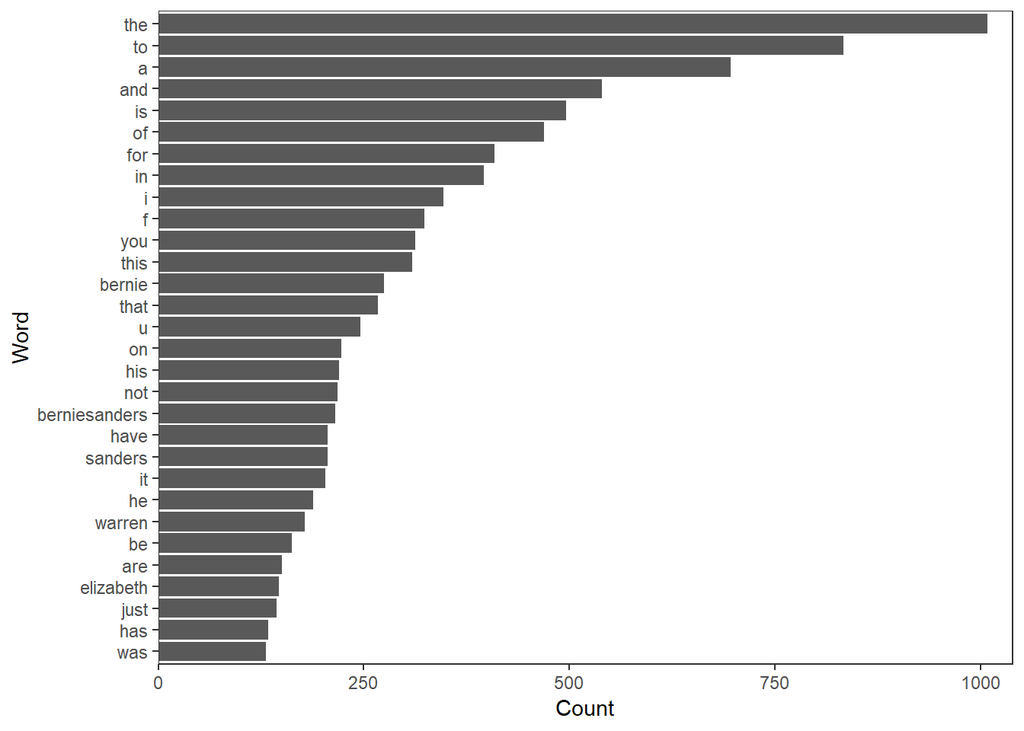

```r
frequent_terms = freq_terms(all_tweets["text"], 30)
plot(frequent_terms)
```

Some of the words are expected, we streamed for tweets about the top four Democratic candidates - so their names are likely to be in the top words. Note that this is counting the number of times these words appear, not the number of tweets in which these words appear. If “Warren” is in one tweet 3 times, it adds 3 instances of “Warren” to the totals reflected above.

We also get words that don’t mean much to us, like the, to, a, etc. These are typically called stopwords. Let’s remove these.

```r
bagCandidates = all_tweets$text %>% iconv("latin1", "ASCII", sub="") %>% scrubber() %sw% qdapDictionaries::Top200Words
```

And now look at the frequent terms again.

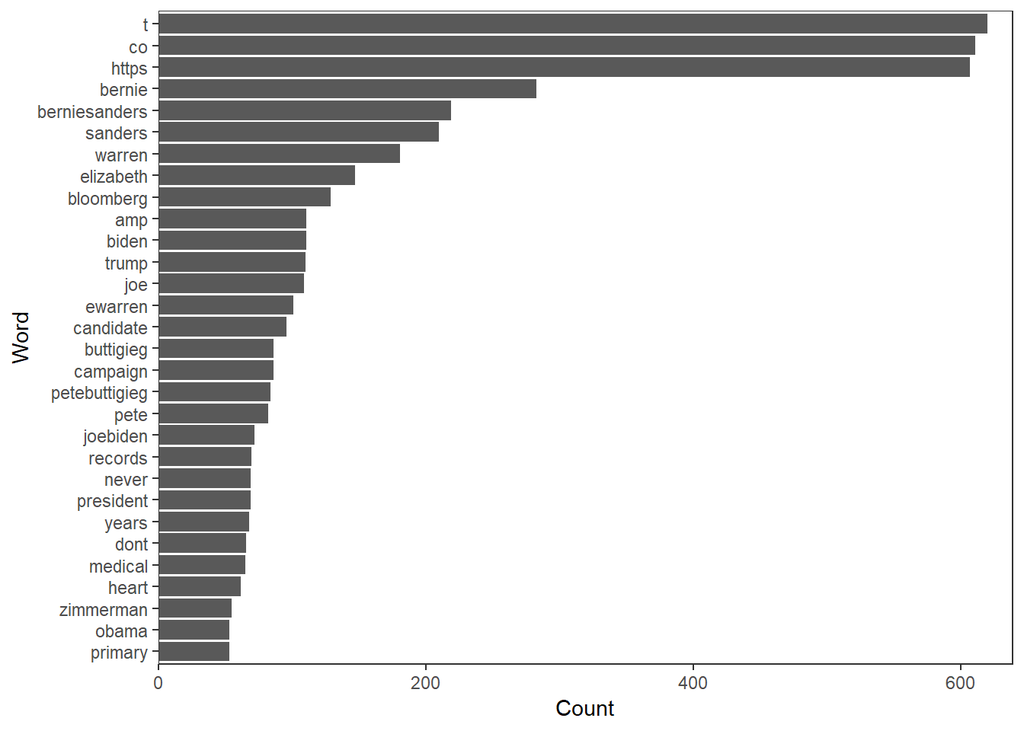

```r
frequent_terms = freq_terms(bagCandidates, 30)
plot(frequent_terms)
```

With the South Carolina primary coming up, let’s say we’re interested in tweets regarding South Carolina. To further analyze those tweets, I could create a dataframe that just includes tweets with the words “South Carolina”.

```r
#install.packages('dplyr')
#install.packages("stringr")

library(dplyr)
library(stringr)
```

```r
candidates_sc = all_tweets%>%filter(str_detect(str_to_lower(text), "south carolina") == TRUE)
head(candidates_sc$text, n=10)
```

```
## [1] "‼️🆘‼️ \nHUGE NEWS!!!!\n\nBernie has now pulled into a TIE for 1st place with Biden in South Carolina. \n\nBiden used to be ahead by 35 points. \n\nChange is coming!"
## [2] "@JoeBiden @MikeBloomberg we need ADS on the AIR in South Carolina IMMEDIATELY showing how Bernie considered primary challenging Obama! JFC Knock him out of 1st ASAP!"
## [3] "‼️🆘‼️ \nHUGE NEWS!!!!\n\nBernie has now pulled into a TIE for 1st place with Biden in South Carolina. \n\nBiden used to be ahead by 35 points. \n\nChange is coming!"
```

# Sentiment Analysis

Now that we have our corpus of tweets from the Twitter API, we can perform a sentiment analysis. We will focus on the `all_tweets’ dataset from above.

## Filtering Out Irrelevant Tweets

There will often be tweets that are not relevant to the analysis at hand. For example, since one of our search words was ‘Warren’, the Twitter API could have given us tweets about Warren Buffet instead of Elizabeth Warren. For the purposes of the primary, Warren Buffet is largely irrelevant, so we want to remove all tweets with the word ‘Buffet’. In the assignment if you want to remove that are about, for example, basketball and hockey, you would change the irrelevant words to: irrelevantWords=c(‘basketball’, ‘hockey’).

```r
#install.packages('quanteda')
library(quanteda)

irrelevantWords = c('buffet')

newTweets = data.frame()
irrelevantTweets = data.frame()

for(i in 1:nrow(all_tweets)){
  # break up tweet into indiviaul words
  tweet = all_tweets$text[i]
  tweet = tolower(tweet)
  words = tokens(tweet)
  # if it contains an irrelevant word, put it in the irrelevant data frame
  if(length(intersect(words$text1, irrelevantWords))>0){
    irrelevantTweets = rbind(irrelevantTweets, all_tweets[i,])
  }
  else{
    newTweets = rbind(newTweets, all_tweets[i,])
  }
}
```

## Sentiment Calculation

To calculate the sentiment of tweets we will be using dictionary-based methods. The first four dictionaries are included in the ‘SentimentAnalysis’ package.

```r
# install.packages('SentimentAnalysis')
library(SentimentAnalysis)
```

The four dictionaries are:

GI– Harvard-IV General Inquirer dictionary

HE– Henry’s finance specific dictionary

LM– Loughran-McDonald financial dictionary QDAP

More detail on this package can be found at: https://cran.r-project.org/web/packages/SentimentAnalysis/SentimentAnalysis.pdf

To see the words in one of these packages:

```r
data('DictionaryGI')
DictionaryGI$positive[1:100]
```

```
##   [1] "abide"           "ability"         "able"
##   [4] "abound"          "absolve"         "absorbent"
##   [7] "absorption"      "abundance"       "abundant"
##  [10] "accede"          "accentuate"      "accept"
##  [13] "acceptable"      "acceptance"      "accessible"
##  [16] "accession"       "acclaim"         "acclamation"
##  [19] "accolade"        "accommodate"     "accommodation"
##  [22] "accompaniment"   "accomplish"      "accomplishment"
##  [25] "accord"          "accordance"      "accountable"
##  [28] "accrue"          "accuracy"        "accurate"
##  [31] "accurateness"    "achieve"         "achievement"
##  [34] "acknowledgement" "acquaint"        "acquaintance"
##  [37] "acquit"          "acquittal"       "actual"
##  [40] "actuality"       "adamant"         "adaptability"
##  [43] "adaptable"       "adaptation"      "adaptive"
```

[output cut: 19 more lines]

```r
DictionaryGI$negative[1:100]
```

```
##   [1] "abandon"        "abandonment"    "abate"          "abdicate"
##   [5] "abhor"          "abject"         "abnormal"       "abolish"
##   [9] "abominable"     "abrasive"       "abrupt"         "abscond"
##  [13] "absence"        "absent"         "absent-minded"  "absentee"
##  [17] "absurd"         "absurdity"      "abuse"          "abyss"
##  [21] "accident"       "accost"         "accursed"       "accusation"
##  [25] "accuse"         "ache"           "acrimonious"    "acrimony"
##  [29] "addict"         "addiction"      "admonish"       "admonition"
##  [33] "adulterate"     "adulteration"   "adultery"       "adversary"
##  [37] "adverse"        "adversity"      "affectation"    "afflict"
##  [41] "affliction"     "afraid"         "against"        "aggravate"
##  [45] "aggravation"    "aggression"     "aggressive"     "aggressiveness"
##  [49] "aggressor"      "aggrieve"       "aghast"         "agitate"
##  [53] "agitation"      "agitator"       "agonize"        "agony"
##  [57] "ail"            "ailment"        "aimless"        "alarm"
##  [61] "alarming"       "alas"           "alibi"          "alien"
##  [65] "alienate"       "alienation"     "allegation"     "allege"
##  [69] "aloof"          "altercation"    "ambiguity"      "ambiguous"
##  [73] "ambivalent"     "ambush"         "amiss"          "amputate"
##  [77] "anarchist"      "anarchy"        "anger"          "angry"
##  [81] "anguish"        "animosity"      "annihilate"     "annihilation"
##  [85] "annoy"          "annoyance"      "anomalous"      "anomaly"
##  [89] "antagonism"     "antagonist"     "antagonistic"   "antagonize"
##  [93] "anti-social"    "antipathy"      "antiquated"     "antitrust"
##  [97] "anxiety"        "anxious"        "anxiousness"    "apathetic"
```

The fifth dictionary is Lexicoder, which consists of word lists for positive, negative, negated positive, and negated negative words.

```r
data_dictionary_LSD2015$negative[1:100]
```

```
##   [1] "a lie"            "abandon*"         "abas*"
##   [4] "abattoir*"        "abdicat*"         "aberra*"
##   [7] "abhor*"           "abject*"          "abnormal*"
##  [10] "abolish*"         "abominab*"        "abominat*"
##  [13] "abrasiv*"         "absent*"          "abstrus*"
##  [16] "absurd*"          "abus*"            "accident*"
##  [19] "accost*"          "accursed*"        "accusation*"
##  [22] "accuse*"          "accusing*"        "acerbi*"
##  [25] "ache*"            "aching*"          "achy"
##  [28] "acomia*"          "acrimon*"         "adactylism*"
##  [31] "addict*"          "admonish*"        "admonition*"
##  [34] "adulterat*"       "adultery*"        "advers*"
##  [37] "affectation*"     "affected*"        "affected manner*"
##  [40] "afflict*"         "affright*"        "affront*"
##  [43] "afraid*"          "against"          "ageism"
```

[output cut: 19 more lines]

```r
data_dictionary_LSD2015$positive[1:100]
```

```
##   [1] "ability*"     "abound*"      "absolv*"      "absorbent*"
##   [5] "absorption*"  "abundanc*"    "abundant*"    "acced*"
##   [9] "accentuat*"   "accept*"      "accessib*"    "acclaim*"
##  [13] "acclamation*" "accolad*"     "accommodat*"  "accomplish*"
##  [17] "accord"       "accordan*"    "accorded*"    "accords"
##  [21] "accountab*"   "accru*"       "accuracy*"    "accurat*"
##  [25] "accustom*"    "ace"          "aced"         "aces"
##  [29] "achiev*"      "acquaintanc*" "acquiesc*"    "active*"
##  [33] "actual"       "actuali*"     "adaptab*"     "adaptive"
##  [37] "adept*"       "adequat*"     "adhere*"      "admirab*"
##  [41] "admiration*"  "admire*"      "admiring*"    "admit*"
##  [45] "adopt*"       "adorable"     "adorably"     "adoration"
##  [49] "adore*"       "adoring"      "adorn*"       "adornment"
##  [53] "adroit*"      "advanc*"      "advantag*"    "adventur*"
##  [57] "advisab*"     "advocacy*"    "advocat*"     "affab*"
##  [61] "affability*"  "affection*"   "affinity*"    "affirm*"
##  [65] "affix*"       "affluent*"    "afford*"      "afloat*"
##  [69] "agil*"        "agree*"       "aid"          "aided"
##  [73] "aids"         "alertness"    "aliv*"        "allay*"
##  [77] "allegian*"    "alleviat*"    "allianc*"     "allied*"
##  [81] "allowab*"     "allowed*"     "allur*"       "ally*"
##  [85] "alright"      "amatory*"     "amaz*"        "ameliorat*"
##  [89] "amenab*"      "amends"       "amiab*"       "amicab*"
##  [93] "amnesty*"     "amore"        "amorous*"     "amour*"
##  [97] "ampl*"        "amus*"        "angel"        "angelic*"
```

```r
data_dictionary_LSD2015$neg_positive[1:100]
```

```
##   [1] "best not"         "better not"       "no damag*"
##   [4] "no no"            "not ability*"     "not able"
##   [7] "not abound*"      "not absolv*"      "not absorbent*"
##  [10] "not absorption*"  "not abundanc*"    "not abundant*"
##  [13] "not acced*"       "not accentuat*"   "not accept*"
##  [16] "not accessib*"    "not acclaim*"     "not acclamation*"
##  [19] "not accolad*"     "not accommodat*"  "not accomplish*"
##  [22] "not accord"       "not accordan*"    "not accorded*"
##  [25] "not accords"      "not accountab*"   "not accru*"
##  [28] "not accuracy*"    "not accurat*"     "not accustom*"
##  [31] "not ace"          "not aced"         "not aces"
##  [34] "not achiev*"      "not acquaintanc*" "not acquiesc*"
##  [37] "not active*"      "not actual"       "not actuali*"
##  [40] "not adaptab*"     "not adaptive"     "not adept*"
##  [43] "not adequat*"     "not adhere*"      "not admirab*"
```

[output cut: 19 more lines]

```r
data_dictionary_LSD2015$neg_negative[1:100]
```

```
##   [1] "not a lie"            "not abandon*"         "not abas*"
##   [4] "not abattoir*"        "not abdicat*"         "not aberra*"
##   [7] "not abhor*"           "not abject*"          "not abnormal*"
##  [10] "not abolish*"         "not abominab*"        "not abominat*"
##  [13] "not abrasiv*"         "not absent*"          "not abstrus*"
##  [16] "not absurd*"          "not abus*"            "not accident*"
##  [19] "not accost*"          "not accursed*"        "not accusation*"
##  [22] "not accuse*"          "not accusing*"        "not acerbi*"
##  [25] "not ache*"            "not aching*"          "not achy"
##  [28] "not acomia*"          "not acrimon*"         "not adactylism*"
##  [31] "not addict*"          "not admonish*"        "not admonition*"
##  [34] "not adulterat*"       "not adultery*"        "not advers*"
##  [37] "not affectation*"     "not affected*"        "not affected manner*"
##  [40] "not afflict*"         "not affright*"        "not affront*"
##  [43] "not afraid*"          "not against"          "not ageism"
```

[output cut: 19 more lines]

To calculate sentiment of each tweet using the ‘SentimentAnalysis’ package:

```r
sentiments = analyzeSentiment(iconv(as.character(newTweets$text), to='UTF-8'))
head(sentiments)
```

```
##   WordCount SentimentGI NegativityGI PositivityGI SentimentHE NegativityHE
## 1         4   0.0000000   0.00000000    0.0000000  0.00000000            0
## 2        25  -0.0800000   0.12000000    0.0400000  0.00000000            0
## 3        28   0.1428571   0.03571429    0.1785714  0.00000000            0
## 4        12   0.0000000   0.16666667    0.1666667  0.08333333            0
## 5        20   0.0500000   0.10000000    0.1500000  0.00000000            0
## 6        10   0.1000000   0.10000000    0.2000000  0.10000000            0
##   PositivityHE SentimentLM NegativityLM PositivityLM RatioUncertaintyLM
## 1   0.00000000  0.00000000   0.00000000          0.0                  0
## 2   0.00000000  0.00000000   0.00000000          0.0                  0
## 3   0.00000000  0.00000000   0.00000000          0.0                  0
## 4   0.08333333 -0.08333333   0.08333333          0.0                  0
## 5   0.00000000 -0.10000000   0.10000000          0.0                  0
## 6   0.10000000  0.10000000   0.00000000          0.1                  0
##   SentimentQDAP NegativityQDAP PositivityQDAP
## 1    0.00000000     0.00000000     0.00000000
## 2   -0.08000000     0.08000000     0.00000000
## 3    0.03571429     0.00000000     0.03571429
## 4    0.00000000     0.08333333     0.08333333
## 5   -0.05000000     0.10000000     0.05000000
## 6    0.00000000     0.10000000     0.10000000
```

The variables are:

WordCount = number of non-stopwords in the tweet

NegativityGI = number of negative words in the tweet that are in the GI negative dictionary / WordCount

PositivityGI = number of negative words in the tweet that are in the GI positive dictionary / WordCount

SentimentGI = PositivityGI - NegativityGI = (# positive words - # negative words) / WordCount

HE, LM, QDAP are similar

When using Lexicoder, we calculate

number of positive words = positive words - negated positive + negated negative

number of negative words = negative words - negated negative + negated positive

```r
tokenized=tokens_lookup(tokens(newTweets$text), dictionary=data_dictionary_LSD2015, exclusive=FALSE)
sentiments$LCpos = sapply(tokenized, function(x) sum(x=='POSITIVE') - sum(x=='NEG_POSITIVE') + sum(x=='NEG_NEGATIVE'))
sentiments$LCneg = sapply(tokenized, function(x) sum(x=='NEGATIVE') - sum(x=='NEG_NEGATIVE') + sum(x=='NEG_POSITIVE'))
sentiments$LC = (sentiments$LCpos-sentiments$LCneg)/sentiments$WordCount
```

To see how the dictionaries compare to each other:

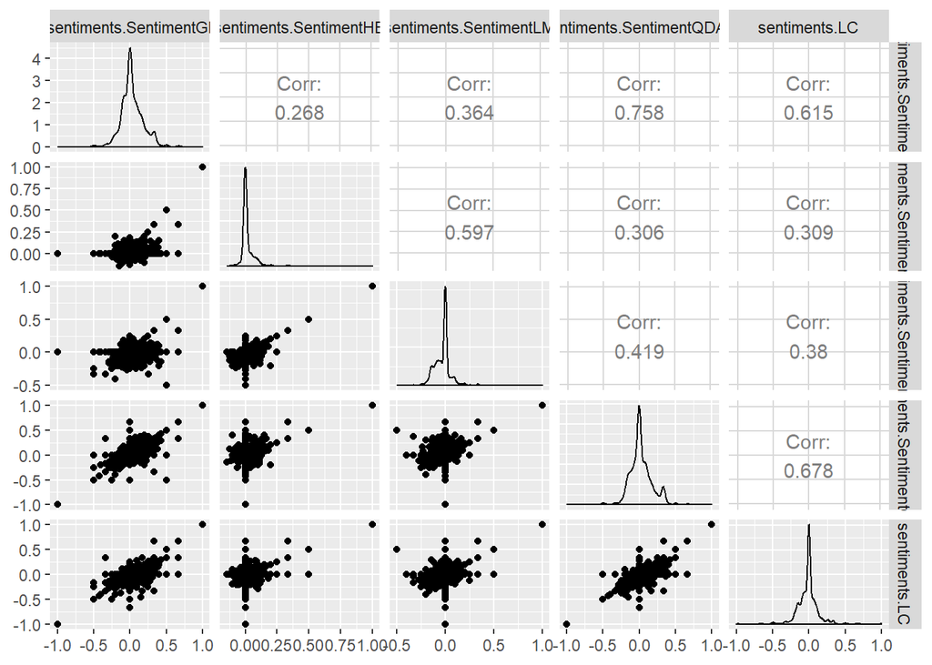

```r
#install.packages('GGally')
library(GGally)
ggpairs(data.frame(sentiments$SentimentGI, sentiments$SentimentHE, sentiments$SentimentLM,
                   sentiments$SentimentQDAP, sentiments$LC))
```

## Sentiment Change Over Time

On the graph below, the x-axis is the time and date the tweet was sent, and the y-axis is the sentiment of the tweet. Since the tweets used were gathered in the time span of one minutes, the x-axis is the second that each tweet was sent.

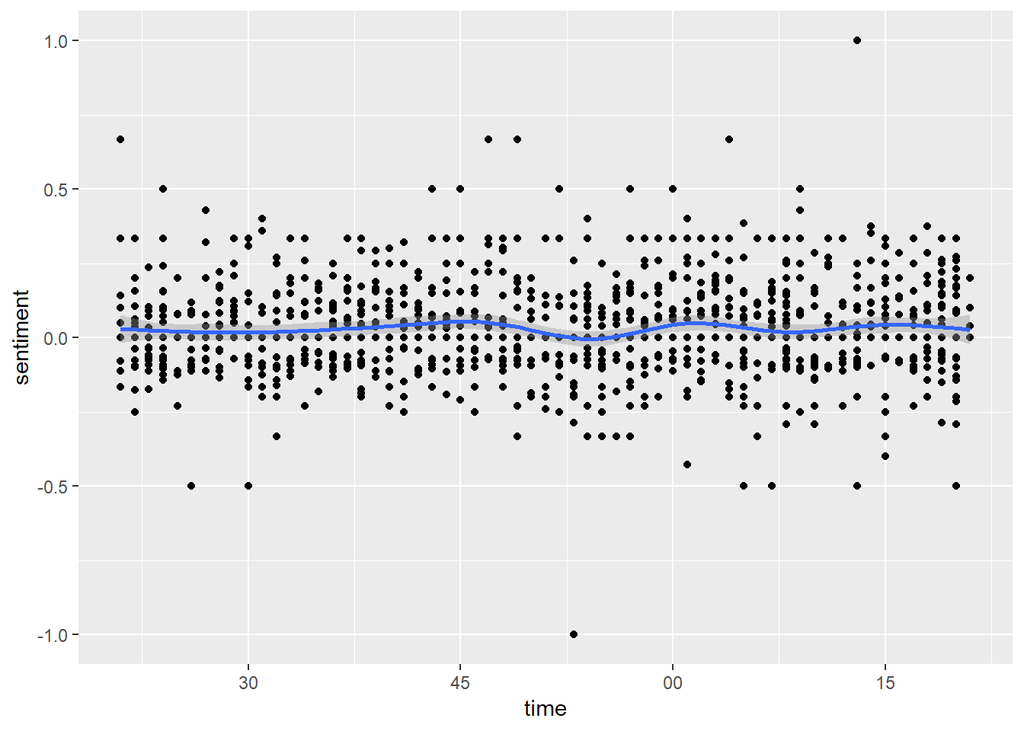

```r
ggplot(data=data.frame(time=newTweets$created_at, sentiment=sentiments$SentimentGI), aes(x=time, y=sentiment)) + geom_point() + geom_smooth()
```

There does not appear to be much of a trend in sentiment of our tweets. Our tweets were collected over a very short timespan; tweets collected over a longer timespan may show more of a pattern.

## Sentiment of retweets vs. original tweets

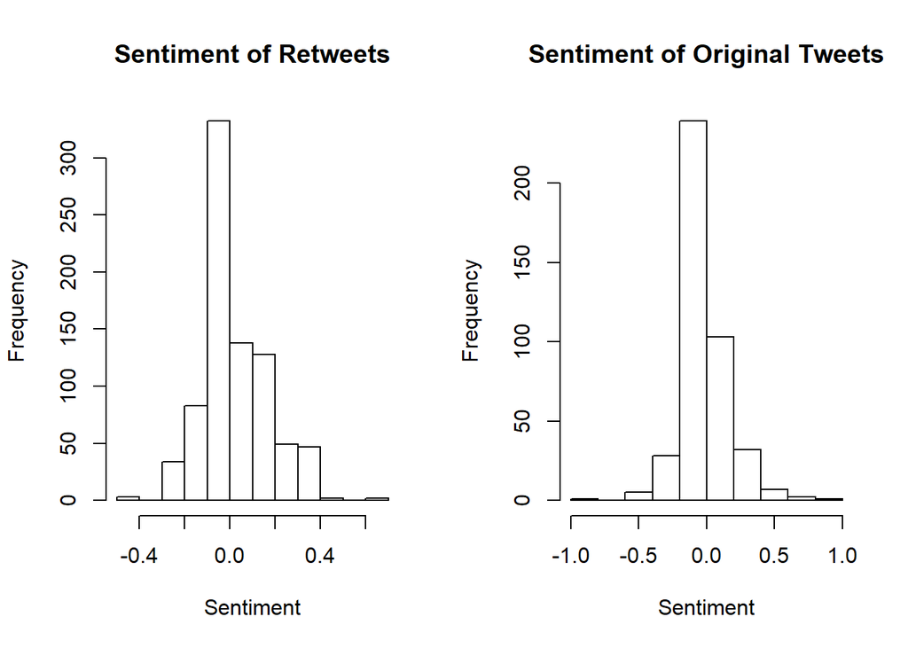

```r
par(mfrow=c(1,2))
hist(sentiments$SentimentGI[newTweets$is_retweet==TRUE], main='Sentiment of Retweets', xlab='Sentiment')
hist(sentiments$SentimentGI[newTweets$is_retweet==FALSE], main='Sentiment of Original Tweets', xlab='Sentiment')
```

```r
par(mfrow=c(1,1))
```

```r
mean(sentiments$SentimentGI[newTweets$is_retweet==TRUE], na.rm=TRUE)
```

```
## [1] 0.03415154
```

```r
mean(sentiments$SentimentGI[newTweets$is_retweet==FALSE], na.rm=TRUE)
```

```
## [1] 0.02147776
```

## Are longer tweets more positive or negative?

In the plot below, the shade of the point refers to how many tweets are at that location. We do not see much of trend. With tweets collected over a longer time period we might see a stronger trend.

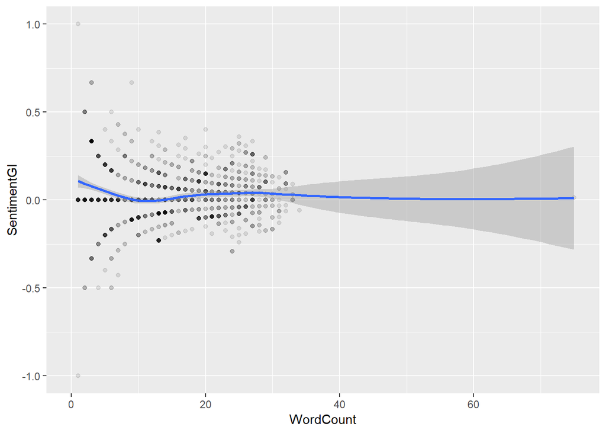

```r
ggplot(sentiments, aes(x=WordCount, y=SentimentGI)) + geom_point(alpha=.1) + geom_smooth()
```